FROM BRAIN TO CONVOLUTIONAL NEURAL NETWORKS

# 뇌학습을 응용한 CNN

인간의 뉴런과 시냅스에서 퍼셉트론, 그리고 이미지 인식 신경망까지

김임환 교수 · 삼성전자 DS교수실

뇌가 경험으로부터 배우는 원리를, 컴퓨터는 어떻게 수학과 회로로 구현했을까?

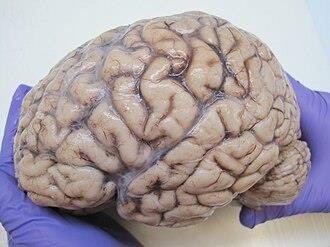

HUMAN BRAIN

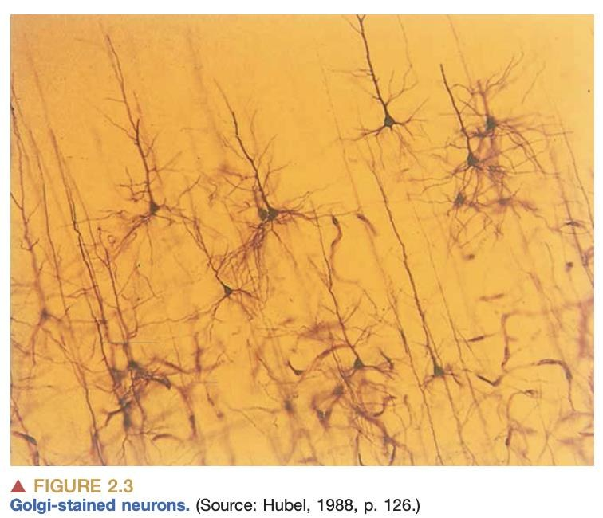

**용어**CNN: 이미지에서 공간적 특징을 학습하는 합성곱신경망. 시냅스: 뉴런 사이에서 신호를 전달하는 접점.

김홍준, 「인지신경과학 관점에서의 인공지능」 pp.6, 15; 강의 재구성: 김임환김임환 교수 · 삼성전자 DS교수실

INTRO

## 오늘의 질문, 다섯 가지

02 / 37

**01**뇌는 정보를 어떻게 받아들이고, 기억하며, 다음 행동을 바꾸는가?

**02**뉴런의 연결 변화는 왜 인공신경망의 가중치와 비교되는가?

**03**퍼셉트론은 어떻게 학습하며, 왜 XOR를 풀지 못하는가?

**04**CNN은 뇌 시각피질에서 어떤 설계 힌트를 얻었는가?

**05**CNN을 반도체 결함 검출에 적용할 때 무엇을 검증해야 하는가?

강의 흐름: 뇌 → 뉴런 → 학습 → 퍼셉트론 → CNN → 반도체 응용

01 · 뇌의 학습

## 뇌는 작은 전력으로 방대한 정보를 처리한다

03 / 37

약 1.3 kg

성인 뇌의 대략적인 질량

약 20 W

에너지 소비의 대략적인 규모

우리가 배울 것은 뇌 전체의 복제가 아니라, 정보 처리 방식에서 얻은 설계 아이디어다.

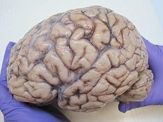

원본 PDF p.6 · 뇌 실물 사진

01 · 뇌의 학습

## 뇌는 한 종류의 계산만 하지 않는다

04 / 37

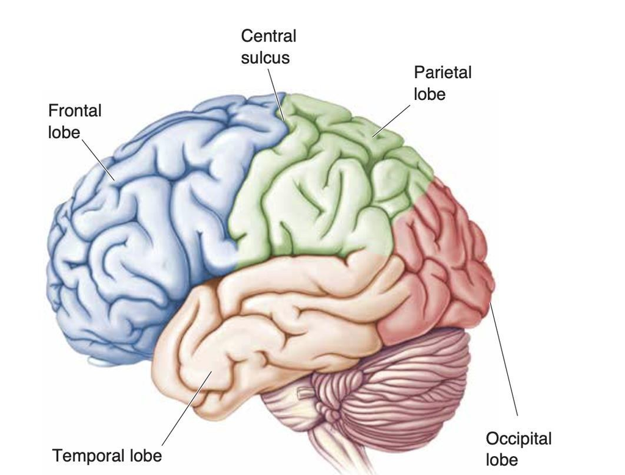

원본 PDF p.30 · 대뇌 영역 구분

후두엽: 시각 신호의 초기 처리에 중요한 영역

측두엽: 청각·물체 인식·기억 등과 연관

전두엽: 계획·의사결정·행동 조절 등에 관여

기능은 구역별로 특화되어도 실제 동작은 넓게 연결된 회로가 협력한다.

CNN과의 연결: 작업을 작은 단계로 나눠 처리하는 계층적 설계

01 · 뇌의 학습

## 뉴런 하나는 신호를 받아서 전달하는 세포다

05 / 37

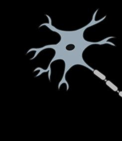

원본 PDF p.16 · 뉴런 형태 도식

가지돌기(Dendrite): 다른 뉴런이 보낸 신호를 주로 받는다.

세포체(Soma): 들어온 신호가 통합되는 과정에 관여한다.

축삭(Axon): 발생한 활동전위를 다음 위치로 전달한다.

축삭 말단: 다른 뉴런과의 시냅스를 형성한다.

인공 뉴런은 이런 복잡한 세포를 ‘입력 → 가중합 → 출력’으로 단순화한다.

01 · 뇌의 학습

## 현미경 속 실제 뉴런과 추상화된 모델

06 / 37

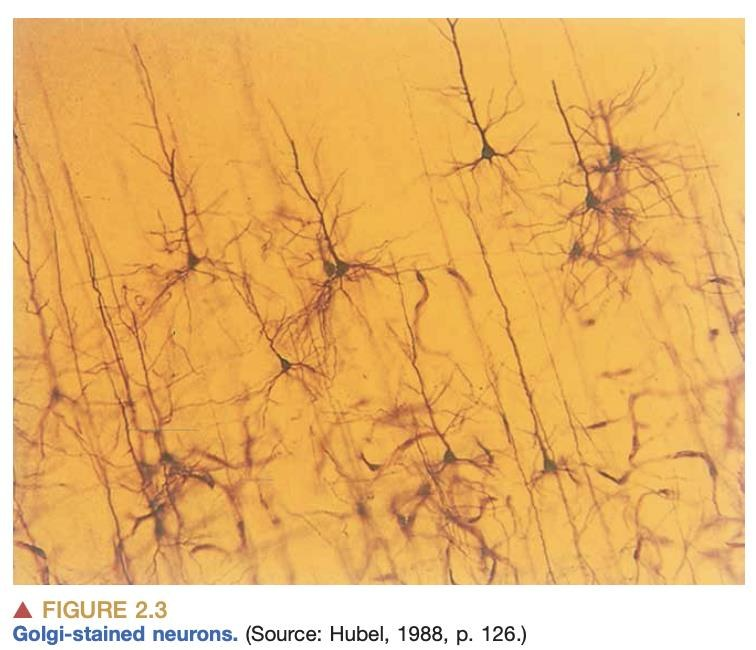

원본 PDF p.15 · 염색한 뉴런의 현미경 사진

생물학적 뉴런

막전위·이온 채널·신경전달물질·수천 개 시냅스 등 다양한 요인이 작용한다.

인공 뉴런

입력값과 가중치를 곱해 더한 뒤, 활성화 함수로 하나의 출력값을 만든다.

인공신경망은 ‘뇌 그 자체’가 아니라 뇌에서 영감을 얻은 계산 모델이다.

01 · 뇌의 학습

## 학습의 핵심은 뉴런 사이의 연결 변화다

07 / 37

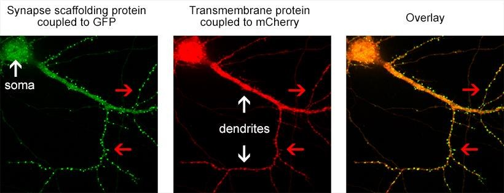

원본 PDF p.17 · 시냅스 형광 현미경 영상

뉴런은 단독으로 지능을 만들지 않는다.

시냅스는 뉴런끼리 신호를 주고받는 접점이다.

학습 경험에 따라 일부 연결의 효율·구조가 변할 수 있다.

인공신경망에서는 이를 가중치의 변화라는 계산적 개념과 연결해 생각한다.

비유: 반복 연습으로 특정 정보가 더 쉽게 전달되는 것처럼, 모델도 학습한 경로의 영향력을 바꾼다.

01 · 뇌의 학습

## 뉴런은 단순한 0·1 스위치보다 복잡하다

08 / 37

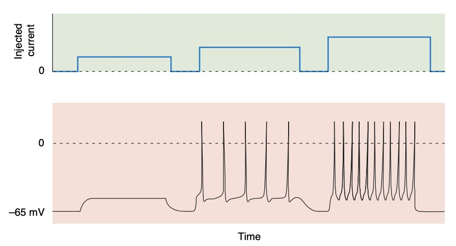

원본 PDF p.19 · 자극 크기와 발화 빈도의 관계

자극이 임계 수준을 넘으면 활동전위가 발생한다.

일정 범위에서 자극이 강해지면 발화 빈도가 달라질 수 있다.

초기 인공 뉴런은 이를 ‘기준을 넘으면 1’이라는 규칙으로 단순화했다.

현대 신경망은 ReLU 등 다양한 수학적 활성화 함수를 사용한다.

뇌의 발화와 ReLU는 닮은 점이 있지만 동일한 메커니즘은 아니다.

01 · 뇌의 학습

## 뇌의 학습: 연결은 강해지기도, 약해지기도 한다

09 / 37

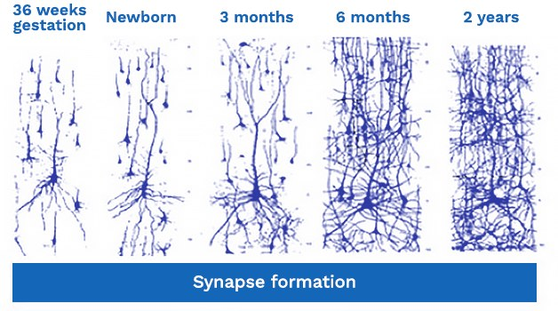

원본 PDF p.28 · 발달기 시냅스 연결 증가

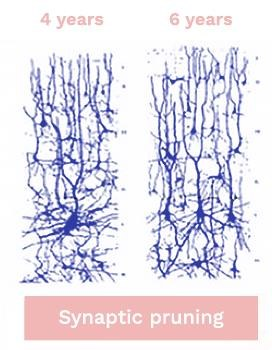

원본 PDF p.28 · 시냅스 가지치기

시냅스 가소성은 생물학적 현상이다. 딥러닝의 가중치 갱신·프루닝은 별도의 수학적·공학적 방법이다.

02 · 퍼셉트론

## Hebb의 통찰: 함께 활성화되면 연결이 바뀐다

10 / 37

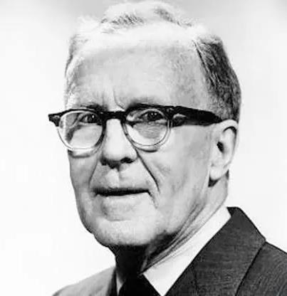

원본 PDF p.27 · Donald Hebb 사진

“함께 활성화되는 뉴런들의 연결은 강화될 수 있다.”

1949년 Hebb의 학습 가설은 경험에 따른 연결 변화에 주목했다.

단순한 Hebbian 학습식: Δw ∝ (입력 활동) × (출력 활동)

현대 딥러닝의 역전파는 이 규칙과 동일하지 않다.

핵심 질문: 경험을 수치로 표현한다면, 어떤 값을 바꿔야 하는가?

02 · 퍼셉트론

## 1943년: 생물학적 뉴런을 논리 회로로 단순화하다

11 / 37

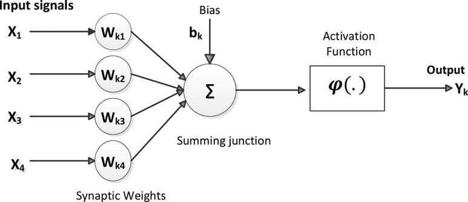

원본 PDF p.43 · 초기 인공 뉴런 개념

여러 입력 신호를 하나의 출력으로 통합한다.

각 입력은 판단 결과에 서로 다른 영향을 줄 수 있다.

기준값을 넘었는지에 따라 출력이 결정된다.

1943년 McCulloch–Pitts 모델은 뉴런의 논리 계산 가능성을 제시했다.

아직 핵심 질문이 남는다. “가중치는 사람이 정할까, 기계가 스스로 배울까?”

02 · 퍼셉트론

## 1958년 Rosenblatt: 컴퓨터가 경험으로 배우도록

12 / 37

1943

McCulloch–Pitts

논리 뉴런

1958

Frank Rosenblatt

퍼셉트론과 학습

1980

Fukushima

Neocognitron

1998

LeNet-5

실용적 CNN

Rosenblatt의 원논문 주제는 단순 분류를 넘어 뇌의 기억과 정보 조직이었다.

감각 입력(S) → 연합(A) → 반응(R) 구조와 연결의 변화로 학습을 설명했다.

“정해진 규칙을 실행하는 기계”에서 “경험으로 규칙을 바꾸는 기계”로.

02 · 퍼셉트론

## 퍼셉트론 한 개가 판단하는 방법

13 / 37

현대적 단순화

z = w₁x₁ + w₂x₂ + w₃x₃ + b

ŷ = step(z)

입력 x: 관측된 특성

가중치 w: 각 특성의 중요도

편향 b: 판단 기준의 조정

출력 ŷ: 모델이 예측한 정답

큰 가중치를 가진 입력은 모델 판단에 더 큰 영향을 미친다.

02 · 퍼셉트론

## 맞혔다면 유지하고, 틀렸다면 가중치를 고친다

14 / 37

01**입력**특성 x가 들어옴

02**예측**현재 가중치로 판단

03**비교**정답 t와 예측 ŷ 비교

04**수정**오류를 줄이는 방향으로 변경

w<sub>새로운</sub> = w<sub>이전</sub> + η(t − ŷ)x

η = 학습률

한 번에 가중치를 얼마나 바꿀지 결정

t − ŷ = 오차

정답과 예측이 얼마나 다른지 표현

x = 입력

어떤 입력이 수정에 기여하는지 결정

학습은 정답을 외워두는 일이 아니라 다음 예측에 쓰일 규칙을 조정하는 과정이다.

02 · 퍼셉트론

15 / 37

AND 진리표

| x₁ | x₂ | 정답 |
| --- | --- | --- |
| 0 | 0 | 0 |
| 0 | 1 | 0 |
| 1 | 0 | 0 |
| 1 | 1 | 1 |

w₁ = 1, w₂ = 1, b = −1.5

02 · 퍼셉트론

## XOR는 왜 단층 퍼셉트론으로 풀 수 없을까?

16 / 37

[figure not shown]

원본 PDF p.44 · AND·OR·XOR의 결정경계 비교

XOR는 입력이 서로 다른 두 점에만 정답 1을 준다.

정답 1인 점들이 대각선에 떨어져 있다.

직선 하나로 네 점을 올바르게 나눌 수 없다.

문제는 데이터 양이 아니라 모델이 표현할 수 있는 경계의 모양이다.

모델을 더 오래 학습시키는 것만으로는 구조적 표현 한계를 해결하지 못한다.

02 · 퍼셉트론

## 해결의 실마리: 뉴런을 여러 층으로 쌓는다

17 / 37

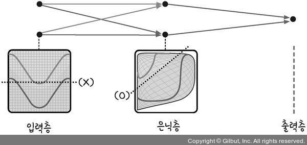

원본 PDF p.45 · 은닉층을 이용한 비선형 분류

입력층이 데이터를 전달한다.

은닉층이 여러 중간 특징을 만든다.

비선형 활성화 함수가 복잡한 경계를 표현하게 한다.

마지막 출력층이 분류를 결정한다.

다층 신경망(MLP)은 XOR처럼 직선 한 개로 풀 수 없는 문제도 표현할 수 있다.

02 · 퍼셉트론

## 역전파: 최종 오류를 앞쪽 연결에도 전한다

18 / 37

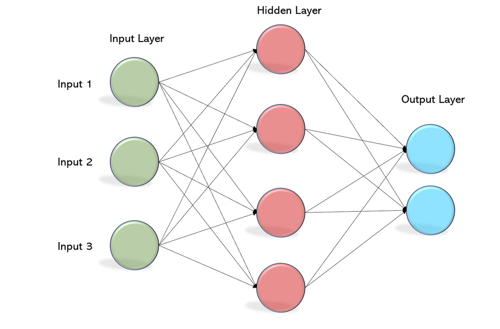

원본 PDF p.49 · 오차역전파 개념

순전파: 입력에서 출력까지 계산한다.

손실함수: 예측이 정답에서 얼마나 벗어났는지 측정한다.

역전파: 연쇄법칙으로 각 가중치의 기여도를 계산한다.

최적화: 기울기를 이용해 가중치를 업데이트한다.

w ← w − η(∂L/∂w)

역전파는 뇌의 시냅스 학습과 동일한 생물학적 법칙이 아니라 계산 효율적인 수학 알고리즘이다.

02 · 퍼셉트론

## 활성화 함수가 신경망을 비선형으로 만든다

19 / 37

### Step

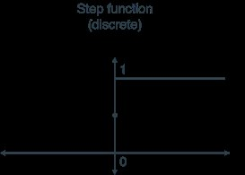

기준에 따라 0 또는 1

### Sigmoid

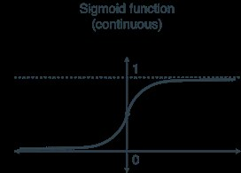

부드럽게 0~1 사이로 변환

### ReLU

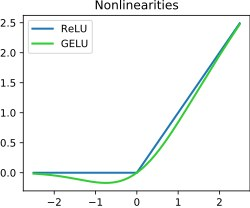

음수는 0, 양수는 그대로

비선형 활성화 함수가 없다면 여러 개의 선형 층을 쌓아도 전체 변환은 선형에 머무른다.

03 · 뇌에서 CNN으로

## 문제 전환: 사진은 숫자지만, 위치 관계도 있다

20 / 37

일반적인 MLP에 이미지를 그대로 펼쳐 넣으면 이웃 픽셀의 관계를 명시적으로 활용하지 못한다.

작은 흠집·선·모서리는 주변 픽셀과의 상대적 배치에서 의미가 생긴다.

CNN은 이미지의 작은 지역을 반복해서 살펴보는 구조를 이용한다.

“어느 픽셀이 밝은가?”에서 “어떤 모양이 어디에 나타나는가?”로 질문이 바뀐다.

03 · 뇌에서 CNN으로

## 시각피질 V1은 단순한 선과 방향에 민감하다

21 / 37

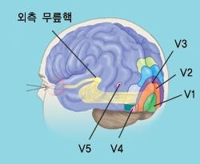

원본 PDF p.56 · V1~V5 시각 영역 도식

시각 정보는 망막에서 시작해 여러 신경 경로를 지나 처리된다.

일차시각피질(V1)의 많은 뉴런은 특정 위치·방향의 선분에 선택적으로 반응한다.

수용장(Receptive field)은 뉴런의 반응을 바꾸는 감각 공간의 범위다.

CNN의 지역 필터는 이 아이디어와 기능적 유사성이 있다.

CNN 필터가 V1 뉴런을 그대로 복제한 것은 아니다.

03 · 뇌에서 CNN으로

## 방향을 가진 선분에 서로 다른 반응을 보인다

22 / 37

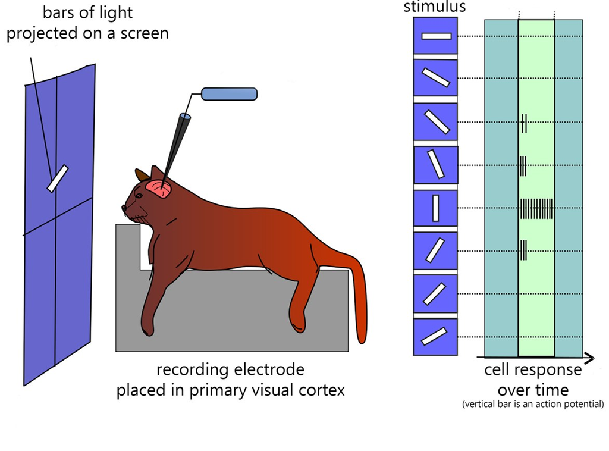

원본 PDF p.56 · 방향 선택성 실험 도식

실험 관찰

막대의 방향을 바꾸면 특정 시각피질 뉴런의 발화 정도가 달라진다.

공학적 아이디어

서로 다른 방향의 선·모서리·패턴에 반응하는 여러 필터를 사용할 수 있다.

CNN의 여러 필터는 학습 과정에서 서로 다른 공간 패턴을 감지하도록 바뀐다.

03 · 뇌에서 CNN으로

## 뇌의 시각 처리처럼, CNN도 특징을 계층적으로 결합한다

23 / 37

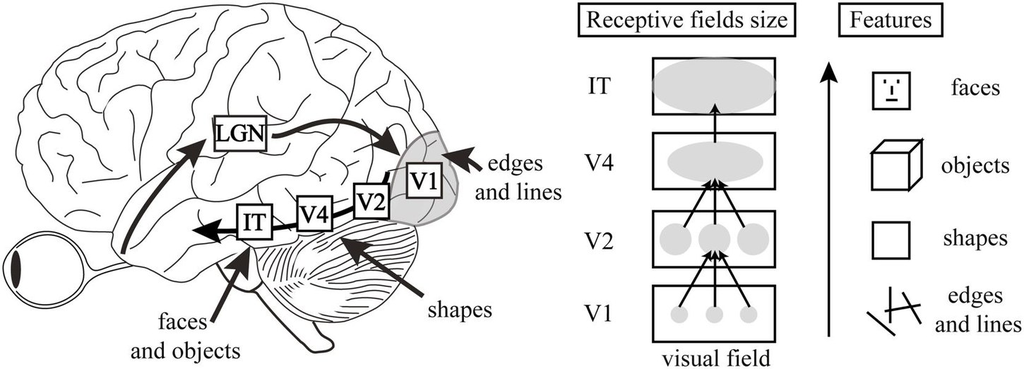

원본 PDF p.57 · 시각 정보의 계층적 처리 개념

초기 단계: 경계선·모서리 등 작은 특징

중간 단계: 질감·곡선·부분 형태

후기 단계: 더 복잡한 물체 관련 표현

CNN도 여러 층을 통과하면서 특징의 조합을 학습한다.

주의: 실제 시각피질의 정보 처리는 단순한 일방향 계단 구조보다 훨씬 복잡하다.

04 · CNN 동작 원리

## 합성곱: 작은 필터를 이미지 위로 이동한다

24 / 37

#### 입력 이미지 5 × 5

×

#### 필터 3 × 3

→

#### 특징맵 3 × 3

수직 경계를 찾아보는 필터

한 칸에서 하는 일

이미지의 3×3 영역과 필터값을 각각 곱해 더한다.

반복해서 얻는 것

필터가 어떤 위치에서 강하게 반응했는지 보여주는 특징맵을 만든다.

필터의 숫자도 학습을 통해 바뀐다. 고정된 이미지 처리 필터와 구별해야 한다.

04 · CNN 동작 원리

## CNN의 두 가지 강점: 지역 연결과 가중치 공유

25 / 37

지역 연결(Local connectivity)

이미지 전체 대신 가까운 픽셀 영역에서 먼저 특징을 계산한다.

작은 흠집·경계의 탐지

가중치 공유(Weight sharing)

같은 필터를 이미지의 여러 위치에서 사용한다.

위치가 달라도 같은 패턴 탐지

예시: 3×3 필터 1개**학습 가중치 9개 + 편향 1개**이미지의 위치 수와 무관하게 같은 필터를 재사용

CNN이 이미지를 잘 다루는 이유는 단지 “층이 많아서”가 아니라 데이터 구조에 맞는 설계 편향 덕분이다.

04 · CNN 동작 원리

## 필터가 많으면 특징맵도 여러 장 생긴다

26 / 37

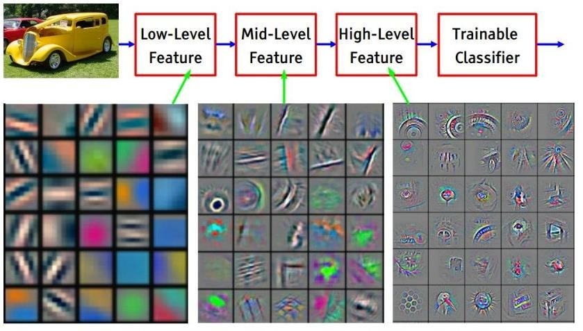

원본 PDF p.60 · 학습된 층별 필터와 특징 시각화

한 개의 필터는 특정 공간 패턴에 반응한다.

필터 여러 개는 서로 다른 특징을 탐지한다.

초기 층과 깊은 층에서 나타나는 특징은 달라질 수 있다.

학습된 필터를 시각화하면 모델이 무엇을 보고 있는지 일부 이해할 수 있다.

반도체 이미지에서는 직선, 스크래치, 이물의 질감, 반복 패턴 등이 유용할 수 있다.

04 · CNN 동작 원리

## 한 장의 사진이 분류 결과로 바뀌는 과정

27 / 37

INPUT

원본 픽셀

CONV

작은 특징 탐지

ACTIVATION

비선형 변환

POOL / STRIDE

공간 크기 조절

CLASSIFIER

정상 / 결함

합성곱→활성화→다운샘플링을 반복하며 공간적 표현을 축적한다.

최종 특징을 바탕으로 분류 또는 위치 예측을 수행한다.

현대 CNN은 구조가 다양하며 모든 모델이 풀링이나 완전연결층을 반드시 사용하는 것은 아니다.

04 · CNN 동작 원리

## Neocognitron에서 LeNet, AlexNet으로

28 / 37

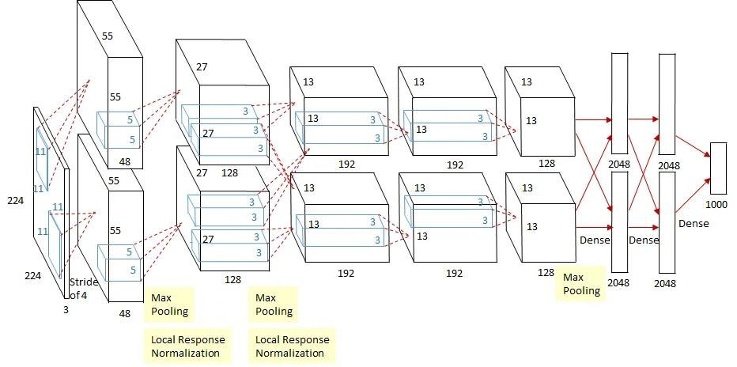

원본 PDF p.59 · CNN 계열 초기 아키텍처 도식

1980 — Fukushima: Neocognitron, 계층적 시각 인식

1989~1998 — LeCun 연구진: 역전파를 이용한 합성곱 신경망과 LeNet-5

2012 — AlexNet: 대규모 이미지 분류에서 GPU 기반 CNN의 성과 부각

이후 — VGG·ResNet·MobileNet 등 다양한 정확도·효율성 개선

핵심은 단일 발명보다, 뇌의 영감·수학·데이터·연산장치가 함께 발전했다는 사실이다.

04 · CNN 동작 원리

## CNN은 뇌를 닮았지만, 뇌와 같지는 않다

29 / 37

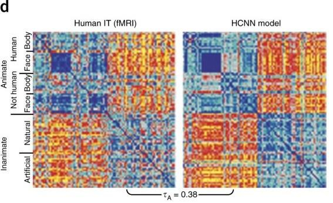

원본 PDF p.61 · 뇌와 모델의 반응 패턴 비교 연구

닮은 점

지역 수용장, 계층적 특징 처리, 일부 시각 반응 패턴에서 유사성이 관찰된다.

다른 점

실제 뇌에는 피드백, 주의, 시간 동역학, 생화학적 학습 등 복잡한 과정이 있다.

뇌 유사성 지표가 높다고 해서 “뇌가 하는 방식 그대로 추론한다”는 뜻은 아니다.

05 · 반도체 응용

## 반도체 검사: 사람이 눈으로 찾던 패턴을 CNN으로

30 / 37

정상 패턴

반복적인 회로·표면 구조

→

스크래치

결함 패턴

스크래치·파티클·얼룩 등

→

CNN 예측 예시

0.92

결함 점수

임계값과 실제 검증 필요

도식은 실제 웨이퍼 사진이나 검증 결과가 아닌 교육용 예시다. 실제 현장에서는 데이터 정의부터 검증해야 한다.

05 · 반도체 응용

## 세 가지 과제는 서로 다른 모델과 검증이 필요하다

31 / 37

01 · 이미지 분류

한 장 전체가 정상인지 불량인지 판정한다.

결과: 정상 / 결함

02 · 객체 탐지

이미지의 어느 위치에 결함이 있는지 상자로 표시한다.

결과: 결함 위치·종류

03 · 분할

결함이 차지하는 픽셀 영역을 구체적으로 표시한다.

결과: 결함의 면적·형상

판정 목적이 다르면 정답 데이터(라벨), 평가 지표, 필요한 CNN 구조도 달라진다.

목표가 “불량 웨이퍼를 가려내기”인지, “불량 원인을 찾아 공정을 개선하기”인지 먼저 구분한다.

05 · 반도체 응용

## 학습 정확도가 99%여도 현장 성능은 다를 수 있다

32 / 37

예시

99%

훈련 데이터 정확도

새로운 장비·로트·공정에서도  
같이 동작한다는 보장은 없다.

학습·검증·테스트 데이터를 독립적으로 나눈다.

동일 웨이퍼의 유사 이미지가 학습과 테스트에 동시에 들어가지 않게 한다.

불량률이 낮으면 정확도 외에 재현율·정밀도·F1을 함께 본다.

장비·로트·촬영조건이 바뀐 외부 데이터로 검증한다.

CNN 연구의 품질은 “훈련 정확도”보다 “보지 못한 현장에서의 일반화”로 판단한다.

05 · 반도체 응용

## CNN 학습의 다음 질문은 “어디서 실행할까?”

33 / 37

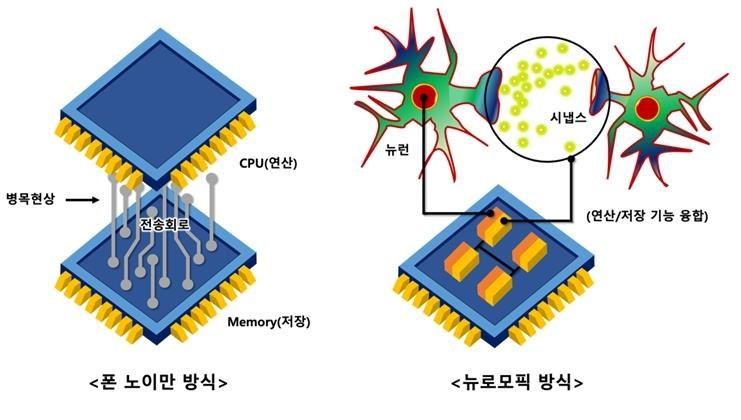

원본 PDF p.63 · 기존 컴퓨팅 구조와 뉴로모픽 개념

학습: GPU 서버에서 많은 데이터를 이용해 가중치를 계산한다.

추론: 검사 장비·엣지 장치에 모델을 배치할 수 있다.

전력·지연·메모리의 제약이 있으면 경량화가 중요해진다.

뉴로모픽 반도체는 뇌의 신호 처리 원리에서 더 직접적인 영감을 얻는 별도 연구 방향이다.

GPU 기반 CNN과 뉴로모픽 칩은 같은 말이 아니다. 하드웨어 목표와 계산 방식이 다르다.

06 · 실습과 토론

## 학생 실습: 같은 데이터로 퍼셉트론과 CNN 비교

34 / 37

1

AND 학습

단층 퍼셉트론으로 가중치 갱신을 직접 관찰한다.

2

XOR 실험

단층의 실패를 확인하고 은닉층을 추가한다.

3

CNN 실험

작은 이미지 데이터에 Conv2D–ReLU–Pooling을 적용한다.

4

해석과 비교

오분류 사례를 보고 일반화·과적합·필터 시각화를 토론한다.

권장 실습 산출물: 학습 곡선, 혼동행렬, 대표 오분류 3개, 개선 아이디어 1개.

06 · 실습과 토론

## 오늘의 이해도 점검

35 / 37

Q1

가중치가 학습된다는 것은 무슨 뜻일까?

정답을 저장하는 것과 무엇이 다른가?

Q2

왜 단층 퍼셉트론은 XOR를 해결하지 못할까?

직선 하나로 네 점을 나눌 수 있는가?

Q3

CNN이 MLP보다 이미지에 적합한 이유는?

지역 연결과 가중치 공유를 설명해 보자.

Q4

반도체 공정 이미지에서 가장 중요한 검증은?

학습과 다른 로트·장비에서도 잘 동작하는가?

OUTRO

## 뇌에서 CNN까지, 반드시 남겨야 할 네 문장

36 / 37

**01**학습은 입력을 외우는 일이 아니라 연결의 영향력을 바꾸는 일이다.

**02**단층 퍼셉트론의 한계는 다층 비선형 신경망의 필요성을 보여준다.

**03**CNN은 시각피질에서 힌트를 얻어 지역 패턴을 계층적으로 학습한다.

**04**반도체 현장에서는 정확도보다 새로운 조건에 대한 일반화가 중요하다.

“생물학의 질문을 수학으로 모델링하고, 회로와 소프트웨어로 검증한다.”

APPENDIX

## 자료 출처와 사용 범위

37 / 37

**01**

김홍준, 「인지신경과학 관점에서의 인공지능」, 122쪽. 제공 PDF에서 뇌·뉴런·시냅스·시각피질·CNN 관련 이미지를 교육 목적으로 발췌.

**02**

Frank Rosenblatt (1958), “The Perceptron: A Probabilistic Model for Information Storage and Organization in the Brain,” Psychological Review, 65(6), 386–408.

**03**

McCulloch & Pitts (1943), “A Logical Calculus of the Ideas Immanent in Nervous Activity.”

**04**

D. O. Hebb (1949), The Organization of Behavior; K. Fukushima (1980), “Neocognitron.”

**05**

Y. LeCun et al. (1998), “Gradient-Based Learning Applied to Document Recognition”; A. Krizhevsky et al. (2012), “ImageNet Classification with Deep Convolutional Neural Networks.”

**06**

도식·수치·퀴즈·반도체 응용 예시는 강의용으로 재구성했으며, 출처 PDF의 제삼자 삽화 원저작권은 각 권리자에게 있습니다.

원본 PDF 사진·삽화는 제공된 강의 자료에서 인용했습니다. 공개 배포 시 개별 이미지의 원저작권과 이용 조건을 확인하세요.

1 / 37